# Burrito

Christopher Juncosa

12/7/2017

## San Diego Burrito Dataset

Who doesn’t like a good burrito, amirite? I thought so. Well thanks to Scott Cole we have an awesome dataset of a bunch of burritos in San Diego. What can we learn about a burrito from this data? So much! First, what did we get in this data?

```r
require(randomForest)
require(ggplot2)
require(sjPlot)
set_theme(base=theme_minimal())
burritoData<-read.csv("Burrito.csv")
ls(burritoData)
```

```
##  [1] "Address"        "Avocado"        "Bacon"          "Beans"
##  [5] "Beef"           "Bell.peper"     "Burrito"        "Cabbage"
##  [9] "Carrots"        "Cheese"         "Chicken"        "Chile.relleno"
## [13] "Chips"          "Cilantro"       "Circum"         "Corn"
## [17] "Cost"           "Date"           "Density..g.mL." "Egg"
## [21] "Fillings"       "Fish"           "Fries"          "Google"
## [25] "Guac"           "Ham"            "Hunger"         "Length"
## [29] "Lettuce"        "Lobster"        "Location"       "Mass..g."
## [33] "Meat"           "Meat.filling"   "Mushroom"       "Neighborhood"
## [37] "NonSD"          "Nopales"        "Notes"          "Onion"
## [41] "overall"        "Pico"           "Pineapple"      "Pork"
## [45] "Queso"          "Rec"            "Reviewer"       "Rice"
## [49] "Salsa"          "Salsa.1"        "Sauce"          "Shrimp"
## [53] "Sour.cream"     "Sushi"          "Synergy"        "Taquito"
## [57] "Temp"           "Tomato"         "Tortilla"       "Uniformity"
## [61] "Unreliable"     "URL"            "Volume"         "Wrap"
## [65] "Yelp"           "Zucchini"
```

So much good stuff here. There is some ambiguity in the naming conventions here, specifically variables like “Ham”, “Clinantro”, and “Salsa” are categorical not continuous, in this case present or absent. Adding the prefix ‘has’ helps me keep things straight and also we’ll recode the (,x) to (0,1) and get rid of some NAs that crept in there. We’ll also drop hasQueso as there aren’t any data points in there and I found it just cause me headache in the analysis as well, and finally some non-sensical rows at the end that excel kindly privided for us.

```r
colnames(burritoData)[32:66] <- paste("has", colnames(burritoData[,c(32:66)]), sep = "")
burritoData[,32:66] <- lapply(burritoData[,32:66], factor, levels = c("", "x"), labels = c(0,1))
burritoData <- subset(burritoData, select = -c(hasQueso))
burritoData <- subset(burritoData[1:382,])
ls(burritoData)
```

```
##  [1] "Address"          "Burrito"          "Chips"
##  [4] "Circum"           "Cost"             "Date"
##  [7] "Density..g.mL."   "Fillings"         "Google"
## [10] "hasAvocado"       "hasBacon"         "hasBeans"
## [13] "hasBeef"          "hasBell.peper"    "hasCabbage"
## [16] "hasCarrots"       "hasCheese"        "hasChicken"
## [19] "hasChile.relleno" "hasCilantro"      "hasCorn"
## [22] "hasEgg"           "hasFish"          "hasFries"
## [25] "hasGuac"          "hasHam"           "hasLettuce"
## [28] "hasLobster"       "hasMushroom"      "hasNopales"
## [31] "hasOnion"         "hasPico"          "hasPineapple"
## [34] "hasPork"          "hasRice"          "hasSalsa.1"
## [37] "hasSauce"         "hasShrimp"        "hasSour.cream"
## [40] "hasSushi"         "hasTaquito"       "hasTomato"
## [43] "hasZucchini"      "Hunger"           "Length"
## [46] "Location"         "Mass..g."         "Meat"
## [49] "Meat.filling"     "Neighborhood"     "NonSD"
## [52] "Notes"            "overall"          "Rec"
## [55] "Reviewer"         "Salsa"            "Synergy"
## [58] "Temp"             "Tortilla"         "Uniformity"
## [61] "Unreliable"       "URL"              "Volume"
## [64] "Wrap"             "Yelp"
```

To answer the age old question, “What makes a great burrito”, lets run a random forest simulation on the data to pick out the ingredients most highly influencing the Overall rating of a burrito. I should mention that the ingredients component of the dataset is a bit funky in that its not complete, so doing the analysis can cause problems particularly if you use a training set and it happens to grab a variable with limited n-size and it depletes the observations and we can’t then compare the results against the test-set. In this case, because its a burrito, we’re good, just an FYI. We’ll also subset here to just handle the ingredients to make the process clearer.

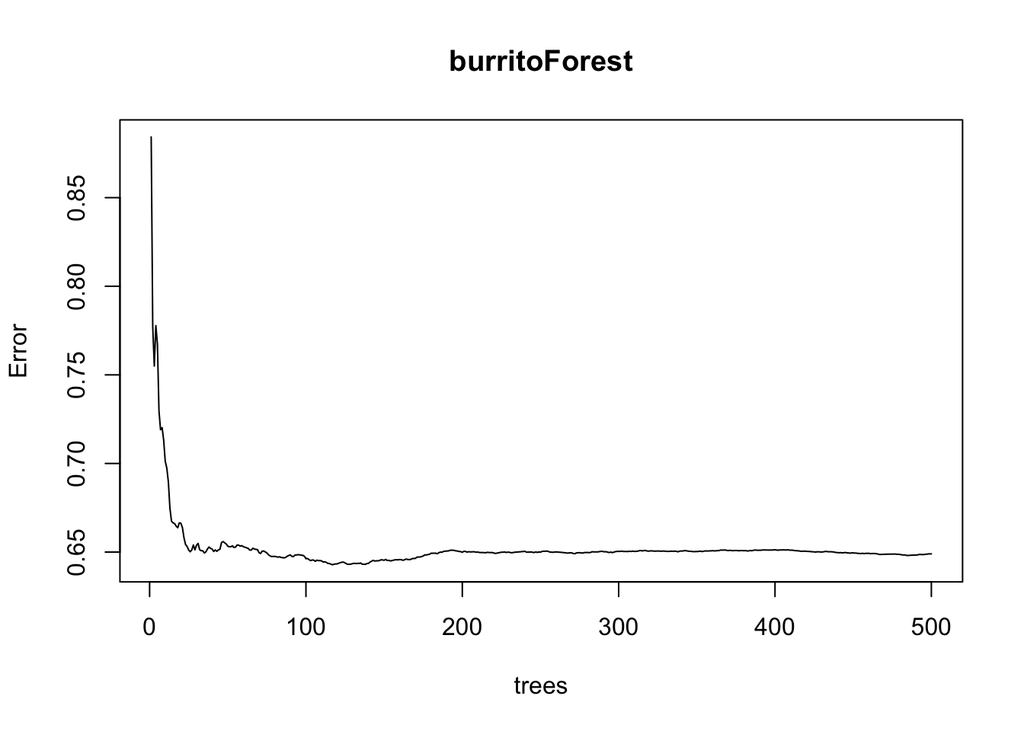

```r
# a 200 datapoint training set
ingredients <- burritoData[,c(26,32:65)]
ingredients[is.na(ingredients)] <- 0
#train<-sample(1:nrow(ingredients),200)
burritoForest=randomForest(overall ~ . , data = ingredients)
plot(burritoForest)
```

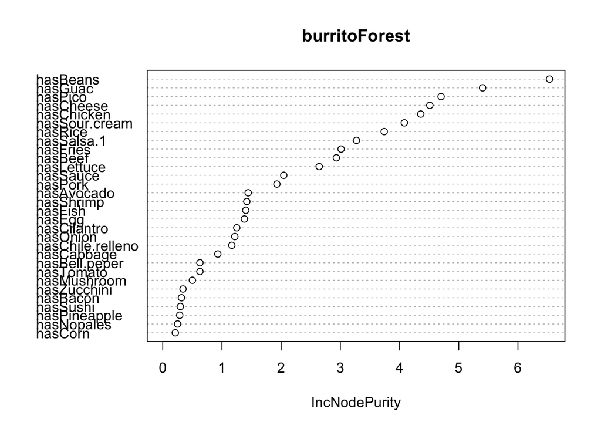

```r
varImpPlot(burritoForest)
```

```r
burritoForest
```

```
##
## Call:
##  randomForest(formula = overall ~ ., data = ingredients)
##                Type of random forest: regression
##                      Number of trees: 500
## No. of variables tried at each split: 11
##
##           Mean of squared residuals: 0.6489977
##                     % Var explained: -0.62
```

## Yelp and Google

Im also curious how a burrito’s rating relates to the restaurant rating, in this case from Yelp and Google.

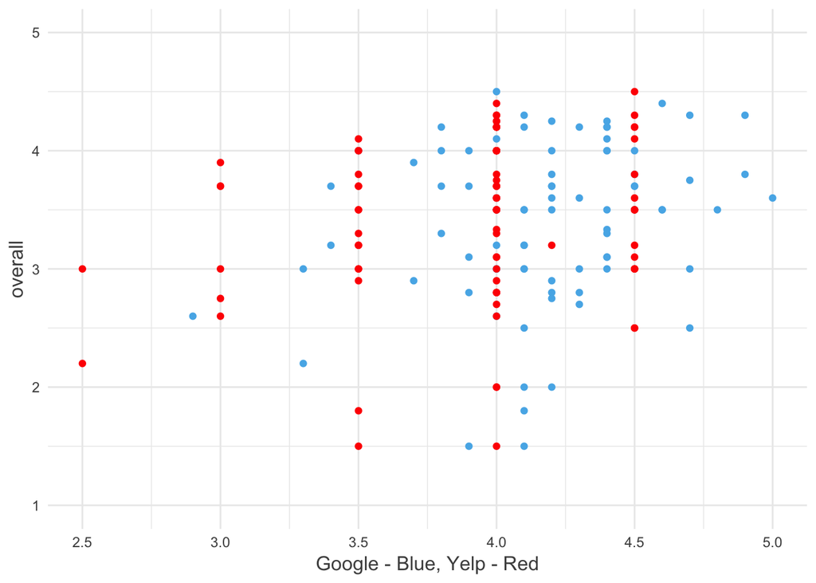

```r
scatterPlot<-ggplot(burritoData) +
  geom_point(aes(x=Google,y=overall), colour='#56B4E9') +
  geom_point(aes(x=Yelp, y=overall), colour="red") +
  theme_minimal() +
  labs(x ="Google - Blue, Yelp - Red")
scatterPlot
```

```r
yelp<-lm(overall~Yelp, data=burritoData)
google<-lm(overall~Google, data=burritoData)
sjt.lm(yelp,google)
```

```
## Fitted models have different coefficients. Grouping may not work properly. Set `group.pred = FALSE` if you encouter cluttered labelling.
```

|  |  | B | CI | p |  | B | CI | p |
| --- | --- | --- | --- | --- | --- | --- | --- | --- |
| (Intercept) |  | 2.29 | 1.06 – 3.53 | <.001 |  | 1.64 | 0.00 – 3.27 | .050 |
| Yelp |  | 0.29 | -0.03 – 0.60 | .075 |  |  |  |  |
| Google |  |  |  |  |  | 0.42 | 0.04 – 0.81 | .033 |
| Observations |  | 82 |  |  |  | 82 |  |  |
| R<sup>2</sup> / adj. R<sup>2</sup> |  | .039 / .027 |  |  |  | .056 / .044 |  |  |

Thats pretty interesting, Yelp rating is barely insignificant, while Google is more significantly correlated. Just goes to show you, never rule out the potential value of a burrito!

Sweet mexican goodness, who’s hungry? This guy. Thats actually a nice seque into something I was curious about: Whats the influence of relative hunger on the rating of a burrito?

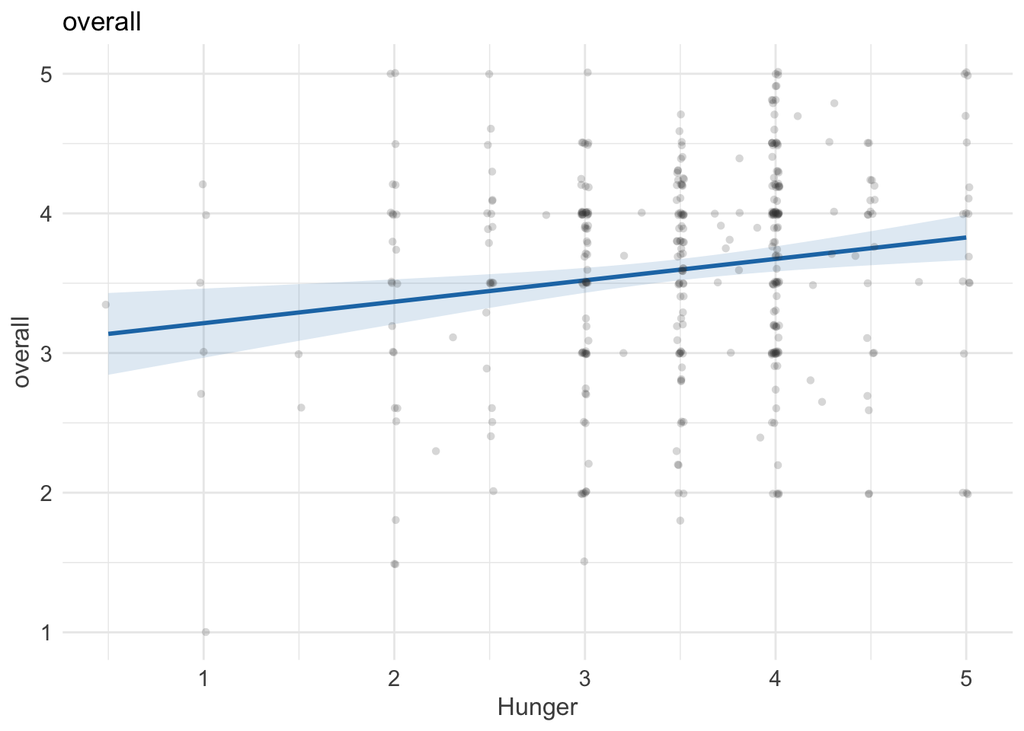

```r
hungerLm<-lm(overall~Hunger,burritoData)
sjp.lm(hungerLm)
```

```r
sjt.lm(hungerLm)
```

|  |  | B | CI | p |
| --- | --- | --- | --- | --- |
| (Intercept) |  | 3.06 | 2.72 – 3.40 | <.001 |
| Hunger |  | 0.15 | 0.06 – 0.25 | .002 |
| Observations |  | 377 |  |  |
| R<sup>2</sup> / adj. R<sup>2</sup> |  | .026 / .024 |  |  |

Yikes. I can’t say Im surprised here either … burritos look good when you’re not hungry, imagine how good they are when you are!